# Campaign Contributions EDA Project

Grigory Makarenko

========================================================

Presidential Map Contributor Dataset from the Federal Election Commission is a dataset of all individual campaign contributions, refunds to individuals, and transfers from authorized committees. This report will explore a subset of this dataset for contributions from Virginia during the 2016 election cycle.

# Univariate Plots

```
## [1] 212849     20
```

```
## 'data.frame':    212849 obs. of  20 variables:
##  $ cmte_id          : Factor w/ 25 levels "C00458844","C00500587",..: 15 15 15 15 6 15 6 7 7 7 ...
##  $ cand_id          : Factor w/ 25 levels "P00003392","P20002671",..: 23 23 23 23 1 23 1 12 12 12 ...
##  $ cand_nm          : Factor w/ 25 levels "Bush, Jeb","Carson, Benjamin S.",..: 23 23 23 23 4 23 4 20 20 20 ...
##  $ contbr_nm        : Factor w/ 50222 levels "'CALLANAN, LISA",..: 40606 38618 36530 38685 15352 36533 9756 27273 22115 19389 ...
##  $ contbr_city      : Factor w/ 1082 levels "","-0352","#NAME?",..: 985 245 382 185 1009 336 717 822 921 622 ...
##  $ contbr_st        : Factor w/ 1 level "VA": 1 1 1 1 1 1 1 1 1 1 ...
##  $ contbr_zip       : num  1.00e+05 2.38e+04 2.24e+04 2.01e+04 2.35e+08 ...
##  $ contbr_employer  : Factor w/ 15300 levels "","-","---","--------------------------------------",..: 10986 6741 6742 12153 13685 10121 1 14323 4836 2747 ...
##  $ contbr_occupation: Factor w/ 8065 levels "","-","--"," ATTORNEY",..: 6102 3520 2114 6818 1103 1929 4773 7068 2256 1081 ...
##  $ contb_receipt_amt: num  80 159.8 74.2 61.3 50 ...
##  $ contb_receipt_dt : Factor w/ 698 levels "01-APR-15","01-APR-16",..: 394 683 110 678 2 218 67 123 123 123 ...
##  $ receipt_desc     : Factor w/ 28 levels "","* EARMARKED CONTRIBUTION: SEE BELOW REATTRIBUTION/REFUND PENDING",..: 1 1 1 1 1 1 1 1 1 1 ...
##  $ memo_cd          : Factor w/ 2 levels "","X": 2 2 2 2 2 2 2 1 1 1 ...
##  $ memo_text        : Factor w/ 119 levels "","$0.06 REFUNDED ON 10/24/2016",..: 1 1 1 1 19 1 19 15 15 15 ...
##  $ form_tp          : Factor w/ 3 levels "SA17A","SA18",..: 2 2 2 2 2 2 2 1 1 1 ...
##  $ file_num         : int  1146165 1146165 1146165 1146165 1091718 1146165 1091718 1077404 1077404 1077404 ...
##  $ tran_id          : Factor w/ 212322 levels "A0007E34E80E24332B58",..: 149473 167695 151160 154165 78276 148413 78316 185367 185275 185050 ...
##  $ election_tp      : Factor w/ 4 levels "","G2016","O2016",..: 2 2 2 2 4 2 4 4 4 4 ...
##  $ cand_party       : Factor w/ 5 levels "DEMOCRATIC","GREEN",..: 5 5 5 5 1 5 1 1 1 1 ...
##  $ cmte_nm          : Factor w/ 25 levels "BERNIE 2016",..: 6 6 6 6 9 6 9 1 1 1 ...
```

This dataset had 20 features and 212849 observations. Most of the features are factor type.

There are 25 different candidates and committees. Contributions to a candidate go through their committee, so they are essentially the same variable. Each candidate/committee is associated with one of 5 parties (in this dataset).

Some of the features have to be adjusted before analysis. The contb_receipt_dt feature needs to be a date type. The contbr_zip is a num type but it would make more sense as a factor type. It might be helpful to convert any zip-plus-4 codes to normal zip codes.

Some features can be removed because they would not contribute to the analysis. cand_id, cmte_id, file_num, and contbr_st do not add any extra information from an analysis perspective. It is interesting that while tran_id is a unique id it has slightly less levels than the number of observations.

```
##                       cand_nm                    contbr_nm
##  Clinton, Hillary Rodham  :111138   TYLER, CAMM       :   669
##  Sanders, Bernard         : 43935   BRADLEY, SAMUEL   :   273
##  Trump, Donald J.         : 24199   NELSON, NANCY     :   258
##  Cruz, Rafael Edward 'Ted': 14076   KHALIQI, AMANULLAH:   237
##  Carson, Benjamin S.      :  8253   ABRAMOWITZ, JEREMY:   233
##  Rubio, Marco             :  3867   STRAYER, IKUKO    :   171
##  (Other)                  :  7381   (Other)           :211008
##           contbr_city       contbr_zip                  contbr_employer
##  ARLINGTON      : 22576   22207  :  5380                        : 32443
##  ALEXANDRIA     : 22017   22314  :  5174   RETIRED              : 26580
##  RICHMOND       :  9320   22101  :  4255   SELF-EMPLOYED        : 12200
##  FALLS CHURCH   :  7422   22201  :  3862   NONE                 :  9797
##  FAIRFAX        :  6808   22204  :  2951   INFORMATION REQUESTED:  7775
##  CHARLOTTESVILLE:  6746   (Other):191216   NOT EMPLOYED         :  5959
##  (Other)        :137960   NA's   :    11   (Other)              :118095
##              contbr_occupation  contb_receipt_amt contb_receipt_dt
##  RETIRED              : 50167   Min.   :-8100     Min.   :2013-12-31
##  NOT EMPLOYED         : 13972   1st Qu.:   19     1st Qu.:2016-03-02
##  ATTORNEY             :  8018   Median :   37     Median :2016-06-21
##  INFORMATION REQUESTED:  7835   Mean   :  134     Mean   :2016-05-26
##  CONSULTANT           :  4826   3rd Qu.:  100     3rd Qu.:2016-09-16
##  TEACHER              :  3343   Max.   :10800     Max.   :2016-12-31
##  (Other)              :124688
##                      receipt_desc    memo_cd
##                            :210317    :168900
##  Refund                    :  1583   X: 43949
##  REDESIGNATION FROM PRIMARY:   179
##  REDESIGNATION TO GENERAL  :   178
##  REATTRIBUTION FROM SPOUSE :   117
##  REATTRIBUTION TO SPOUSE   :   117
##  (Other)                   :   358
##                                memo_text       form_tp
##                                     :144884   SA17A:168438
##  * EARMARKED CONTRIBUTION: SEE BELOW: 43064   SA18 : 42828
##  * HILLARY VICTORY FUND             : 23181   SB28A:  1583
##  *BEST EFFORTS UPDATE               :   289
##  EARMARKED FROM MAKE DC LISTEN      :   196
##  REDESIGNATION FROM PRIMARY         :   179
##  (Other)                            :  1056
##                  tran_id       election_tp          cand_party
##  A8561DEB416064FCF8DB:     4        :   448   DEMOCRATIC :155327
##  A8F1F523F3773412391E:     3   G2016: 84054   GREEN      :   249
##  AE88184060DAC421EA88:     3   O2016:    43   INDEPENDENT:   371
##  SA17.1205546        :     3   P2016:128304   LIBERTARIAN:   584
##  C1014124            :     2                  REPUBLICAN : 56318
##  C1017253            :     2
##  (Other)             :212832
##                                 cmte_nm         contbr_zip_p4
##  HILLARY FOR AMERICA                :111138   232262506:   667
##  BERNIE 2016                        : 43935   22101    :   467
##  DONALD J. TRUMP FOR PRESIDENT, INC.: 24199   22314    :   350
##  CRUZ FOR PRESIDENT                 : 14076   23451    :   339
##  CARSON AMERICA                     :  8253   23188    :   334
##  MARCO RUBIO FOR PRESIDENT          :  3867   (Other)  :210681
##  (Other)                            :  7381   NA's     :    11
```

## Timeline

### Daily

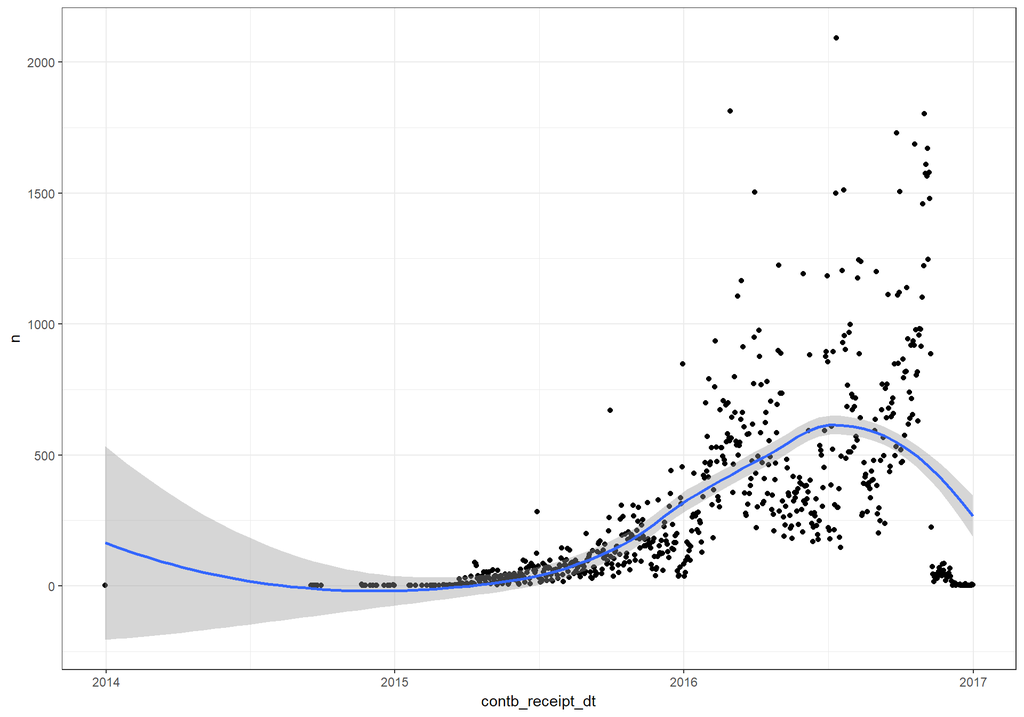

### Monthly Timeline

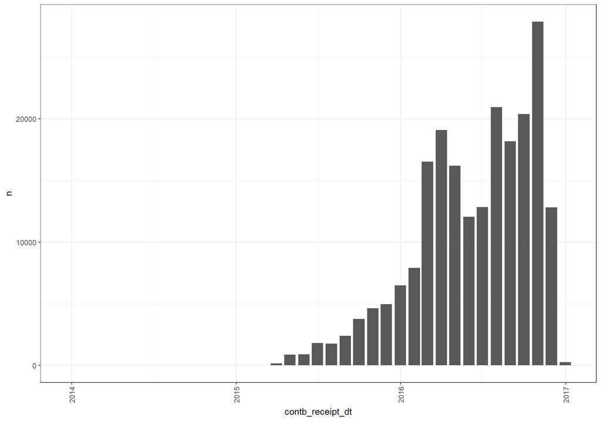

With this division, we can plainly the spikes in contributions by month. We can see that the first uptick was during the primary election from February 2016 to April 2016. Then we have decline followed by big increase in July 2016 leading up to the presidential election in November 2016. October 2016 was the last push to campaign before election day, and it shows in the major increase. It’s interesting that November still had so many contributions even when the election date is so early in the month.

## Candidates

### Candidate Summary

```
## # A tibble: 25 × 2
##                      cand_nm      n
##                        <chr>  <int>
## 1    Clinton, Hillary Rodham 111138
## 2           Sanders, Bernard  43935
## 3           Trump, Donald J.  24199
## 4  Cruz, Rafael Edward 'Ted'  14076
## 5        Carson, Benjamin S.   8253
## 6               Rubio, Marco   3867
## 7                  Bush, Jeb   1510
## 8             Fiorina, Carly   1265
## 9            Kasich, John R.   1170
## 10                Paul, Rand   1016
## # ... with 15 more rows
```

### All contributions

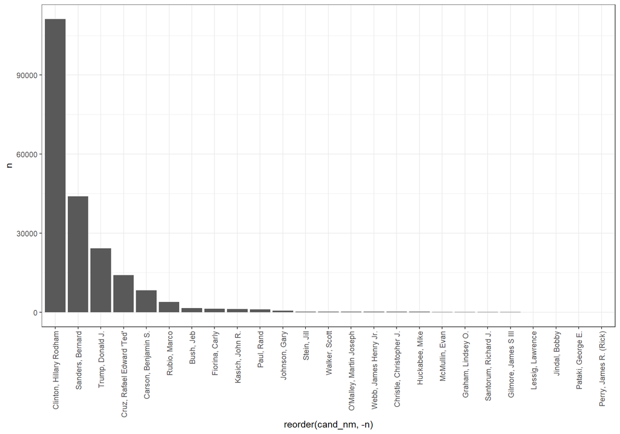

### Less than 15000 contributions

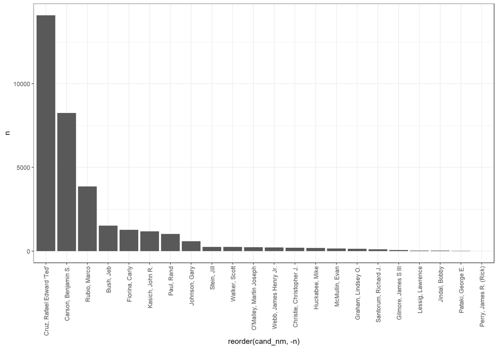

### Less than 5000 contributions

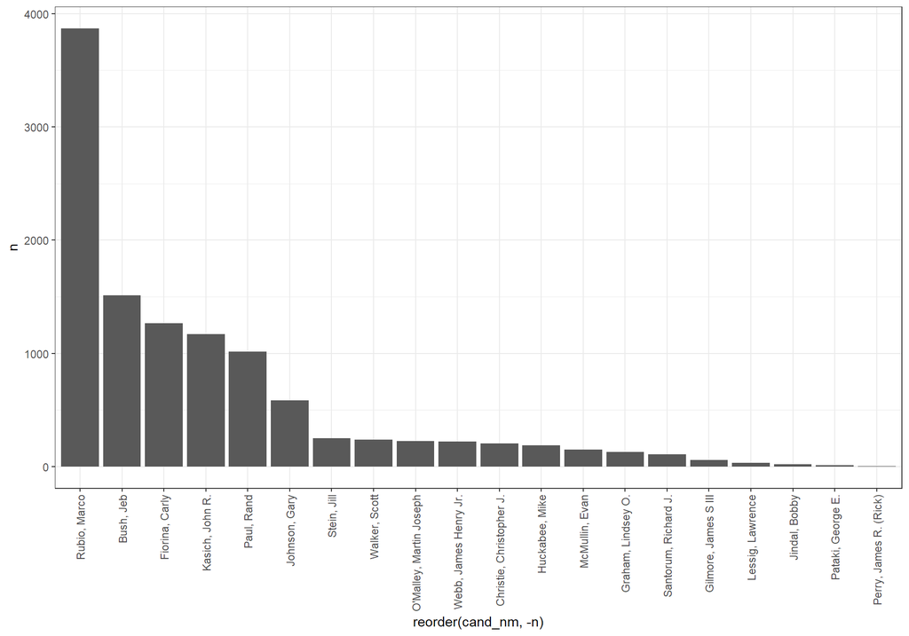

### Less than 500 contributions

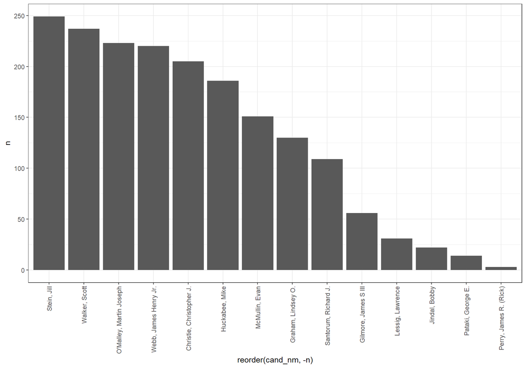

### Party Aggregate

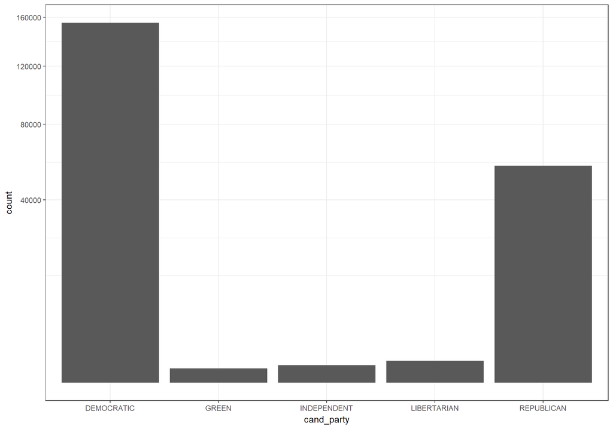

The y axis was scaled by square root to be able to see the low contribution parties.

We can see that most of the candidates got very few contributions compared to Clinton, Sanders, and Trump. Even if the top 3 “outliers” are removed, we can see that most of the 25 candidates received less than 5000 contributions. More than half of the candidates received even less than 250 contributions. It will be interesting to see how the number of contributions relates to the amount contributed. Republicans could be getting less contribution but those contributions have a high receipt amount. So, are the aggregate receipt amounts more even between the parties?

## Geographic Data Graphs

### Cities (Top 20 Count)

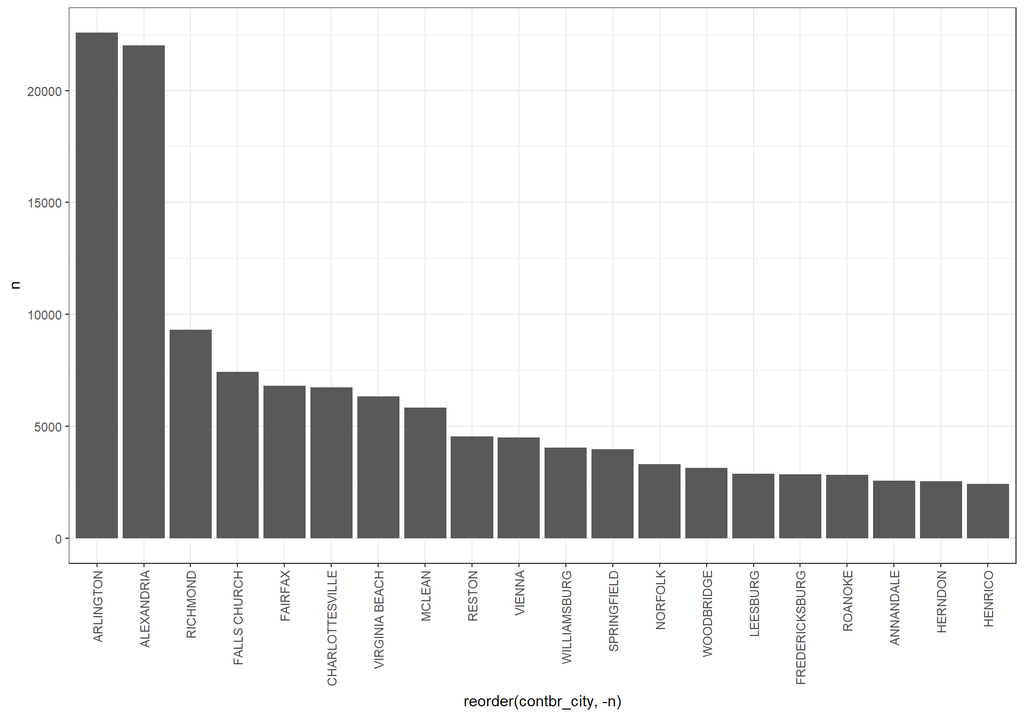

Most of the cities in the top 20 are near Washington, DC. The other ones (Richmond, Virginia Beach) are major population centers. These results aren’t surprising. It is interesting that Henrico is actually the county surrounding Richmond. It is clear that there are some anomalies in the dataset.

We will see that better by looking a the low count cities.

### Cities (Low Counts)

```
## # A tibble: 265 × 2
##             contbr_city     n
##                   <chr> <int>
## 1                 -0352     1
## 2                #NAME?     1
## 3              ABINGSON     1
## 4                ALBANY     1
## 5             ALEXANDER     1
## 6   ALEXANDRIALEXANDRIA     1
## 7  ALEXANDRIANOUSH@AOL.     1
## 8              ALHAMBRA     1
## 9              ANACONDA     1
## 10              ANAHEIM     1
## # ... with 255 more rows
```

There are 265 rows that had a count of 1. Many of these are misspelled names or names of cities outside of Virginia (New York, Las Vegas). While the misspellings could be cleaned up, it doesn’t seem worth the effort for such a low amount relative to the whole sample size.

### Zipcodes

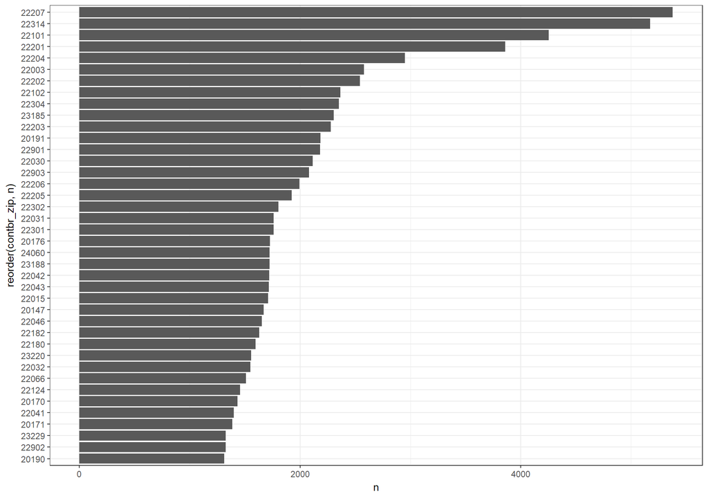

The amount of contributions per zip code looks close to the cities with a few more spikes. Some cities contain several zip codes so much of the spread is just subdivision of the city amounts.

### Zipcodes Distribution

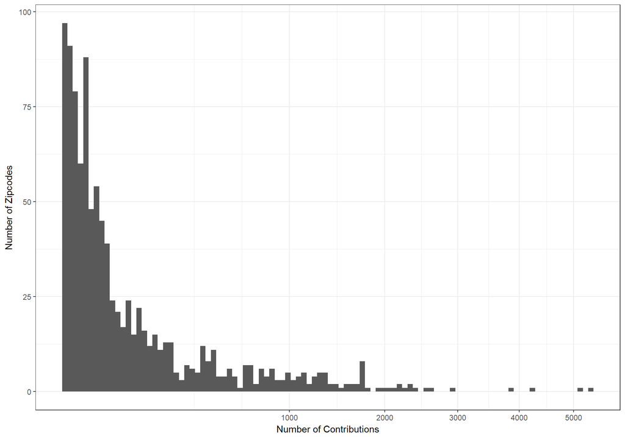

This plot displays how many zipcodes (locations) had certain numbers of contributions, e.g. only two zipcode had more than 5000 contributions.

I scaled the plot by a square root. The histogram shows that most of the zipcodes that were reported in the dateset had less than 500 contributions. Meaning that most of the contributions came from a few zipcodes (or geographic areas).

## Contributor Employment

### Contributor Occupation

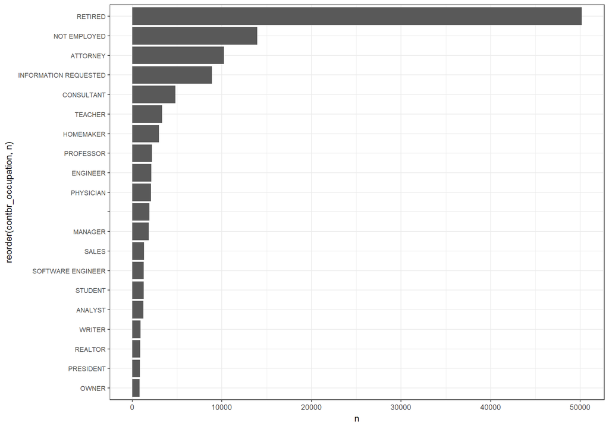

### Contributor Employer

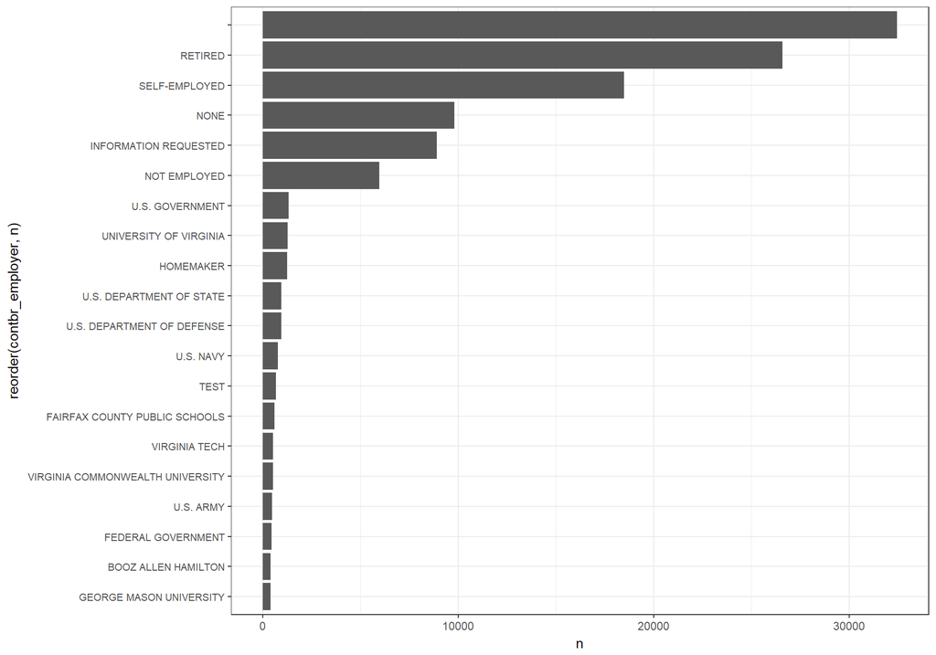

Many of the contributors chose to not give their employer name. Again, many people are retired or have no employer. Interestingly many people report self-employment.

## Contribution Receipt Amount

### Raw Histogram

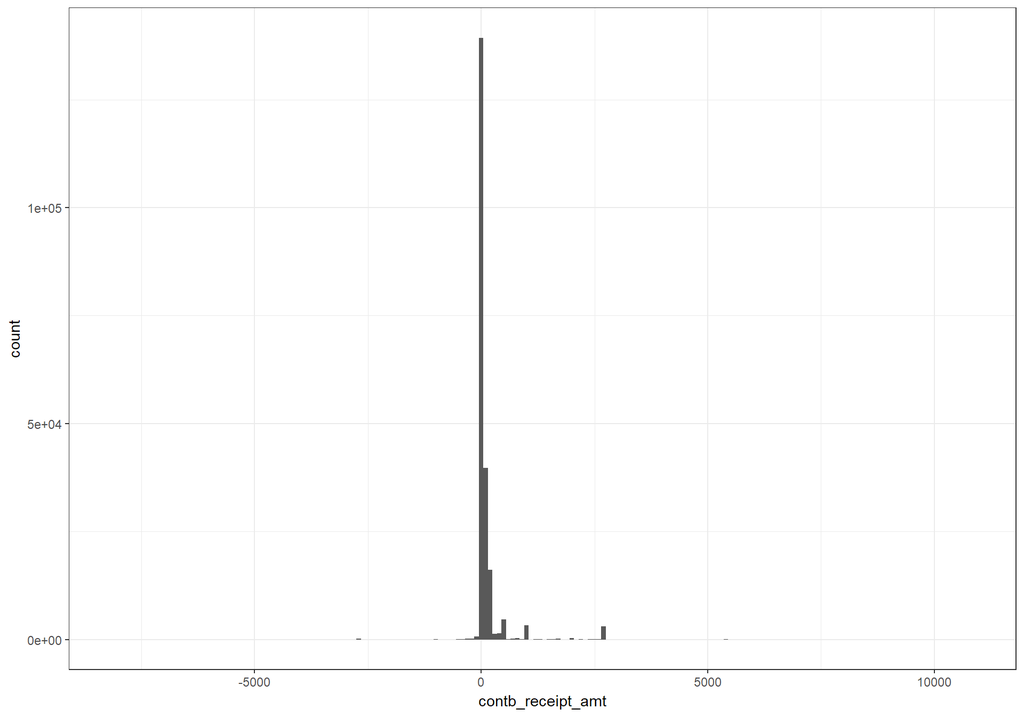

As the summary showed, the median contribution receipt amount is within $100 or $37 to be exact.

### Zoomed Histogram

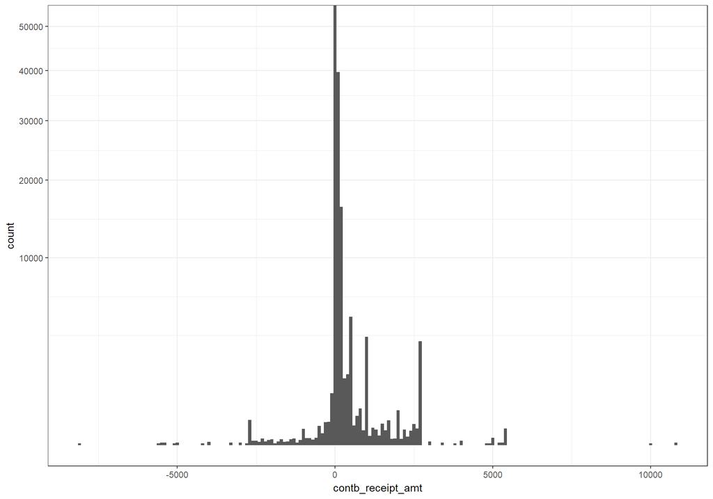

# Univariate Analysis

The committee name and political party features was added to this dataset through a separate python script. Although, the committee features do not give any more information than the candidate name feature.

The zip codes feature was reduced to only 5 digits. Zip code + 4 is very specific, and the change makes it more broad. The receipt date feature had to be changed from a factor type to an actual Date type.

Several features could be cleaned up, but that is unnecessary. For example, we saw that there were several cities that were misspelled or were not Virginia cities. That amount is negligible relative to the dataset, so the effort of cleaning the data would be much higher than the value of the extra datapoint.

```
## # A tibble: 10 × 2
##        nf     n
##    <fctr> <int>
## 1       1   265
## 2       2    88
## 3       3    59
## 4       4    40
## 5       5    26
## 6       6    27
## 7       7    22
## 8       8    20
## 9       9     8
## 10     10    14
```

For the city feature, I will assume that the city names with counts of up to 10 (nf means factor of the count) would have some data that would require cleaning. The count of each of those is above.

```
## # A tibble: 1 × 1
##   `sum(head(n_product, 10))`
##                        <dbl>
## 1                       1596
```

If I take the sum of the products of each of the 10 rows, I can get a rough idea about the amount noisy datapoints we might have (above). So that’s 0.74982734238% of the data points. I think other variables (ie. employer, occupation) with free text input would be similar.

I want to see which variables might affect 1) the candidate or party that is contributed to and 2) the receipt amount of the contribution. The geographic and occupation are the only demographic variables for contributors, so they might not provide much more than basic explanatory power.

# Bivariate Plots

## Receipt Amount over Time

### Receipts Boxplots

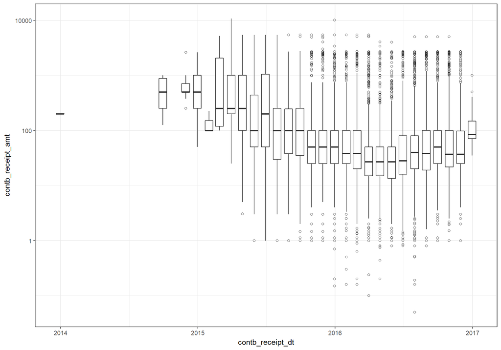

The contibution receipt amount was scaled by a log. Negative receipts were removed.

The mean and median contribution receipt amounts throughout the election are quite interesting. They are almost the opposite of the frequency of contributions in the same time period. Earlier in the election there were fewer contributions per month, so the means are much more heavily affected by any large contribution. This plot is indicating that there are outliers in the data. I do not expect there contributions to be actual outliers, rather they are just very rare for each month’s contribution receipt amounts.

### Aggregate Receipts

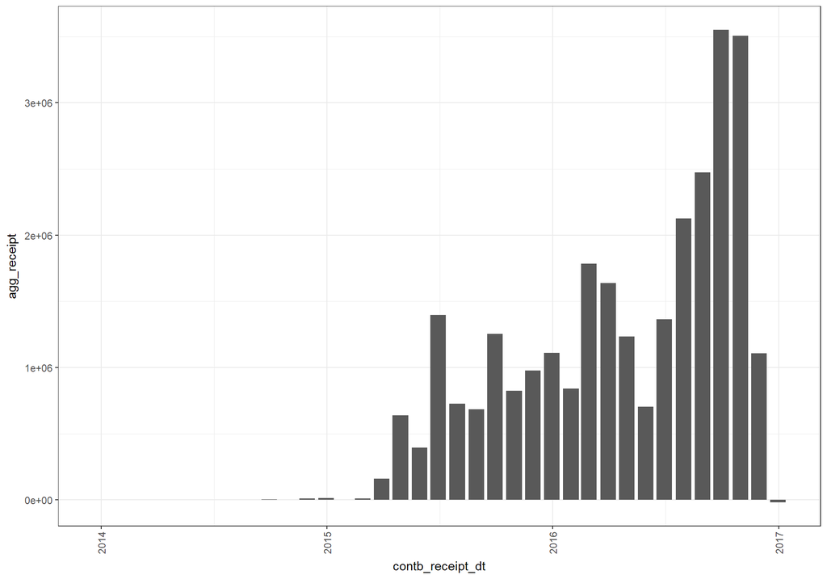

The aggregate receipts per month follow much closer to the contribution counts per month. We can see again that many people contributed around the party primary elections and the general election.

## Amount by Candidate

### Receipts Boxplots

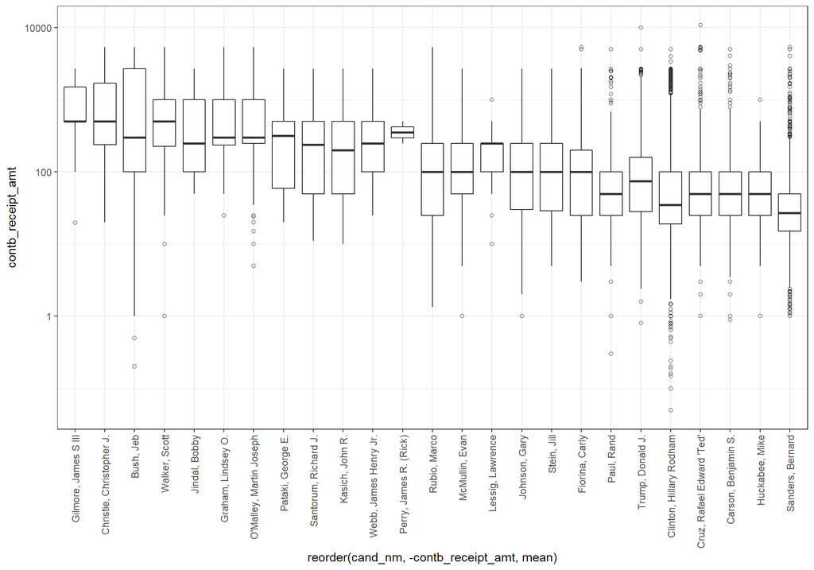

The contibution receipt amount was scaled by a log. Negative receipts were removed. Ordered by mean.

The two democratic candidates that got the most contributions have some of the lowest median and mean receipts. Bernie Sanders’s mean is the lowest out of the group. Ted Cruz and Donald Trump had the largest value receipts, and Hillary Clinton had the lowest value positive receipt.

### Aggregate Receipts

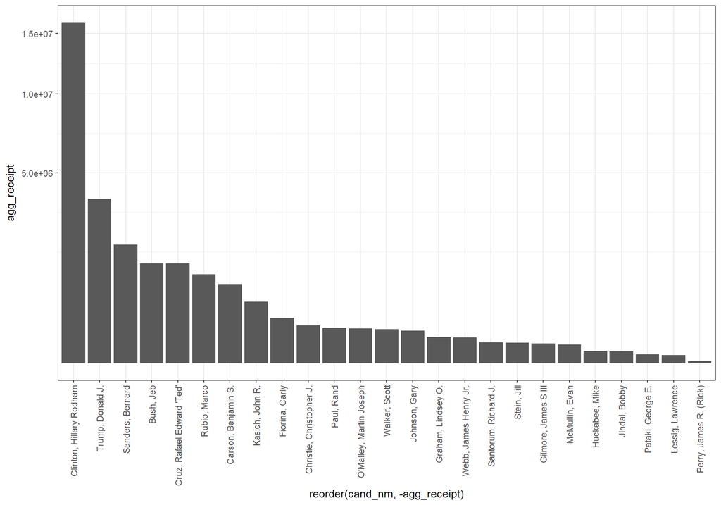

The y axis was scaled by a square root.

Hillary Clinton received the highest amount of money from Virginia contributors by a large margin. It’s surprising that Jeb Bush had a similar aggregate receipt amount as Ted Cruz, but Bush had about 1/10 of the number of contributions as Cruz. Similarly, Bernie Sanders had close to twice the number of contributions as Donald Trump but had half of the aggregate receipt amount.

### Receipt Distribution

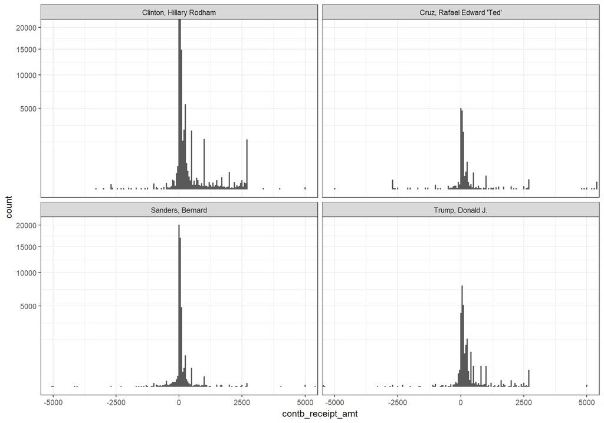

Looking at the receipt distribution of the top 4 candidates (by count), we can see that for each candidate the distribution is heavily centered at contributions that are less than $500. Hillary Clinton’s graph has been reduced, but it reaches up to 50000 contributions in the center. It’s hard to tell whether Ted Cruz’s or Bernie Sanders’s distribution is the most narrow of the 4 cardidates.

### Summary Assessment

It’s clear that Hillary Clinton was the most popular candidate in Virginia. She had the most contributions and did not get the highest aggregate receipts just by high value donations. It isn’t necessary to look at the impact of political party on the number of contributions or the overall receipts, since all the republican candidates combined wouldn’t overtake Hillary Clinton’s aggregate receipts.

## Receipt Amount by Location

### Receipts Boxplots

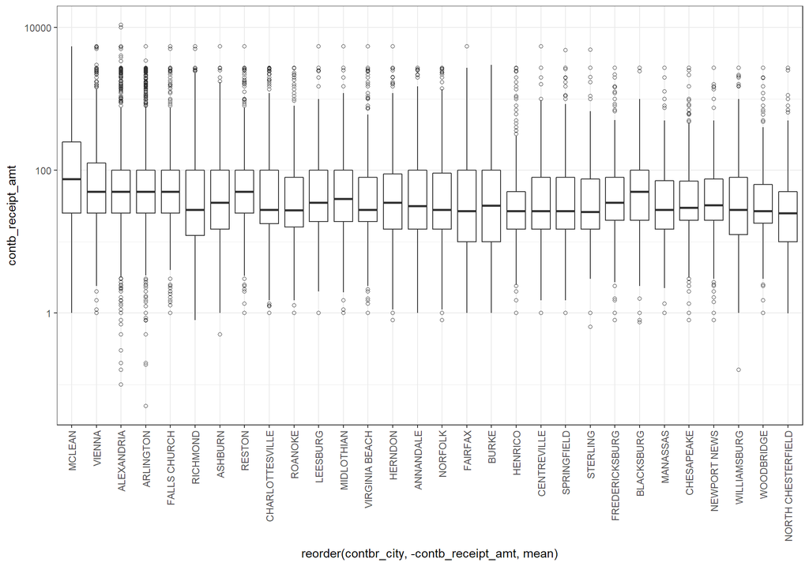

The contibution receipt amount was scaled by a log. Negative receipts were removed. Ordered by mean.

McLean has a significantly higher mean receipt than the rest of the top 30 contributing cities. However, McClean had a significantly lower contribution count than Arlington and Alexandria. It is not surprising that the top 5 cities in this group are in the Northern Virginia area which is, on average, the richest area in Virginia and a Washington, DC suburb. The biggest contribution came from a person in Alexandria, and the rest of the cities’ contributions were quite a bit lower maximum contribution receipt.

### Aggregate Receipt

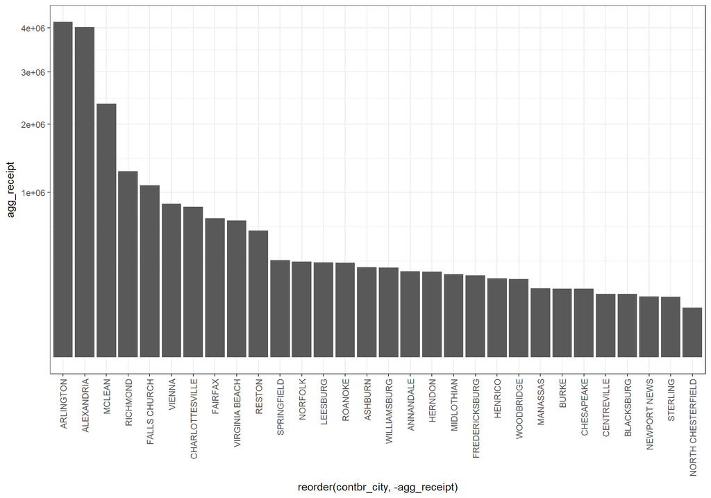

The y axis was scaled by a square root.

As would be expected, Arlington and Alexandria have the highest aggregate contribution receipts. McLean surpassed Richmond, but it had close to half as many contributions as Richmond. McLean did have a much higher mean receipt than every other city.

### Summary Analysis

Generally, the population centers of Virginia are represented on the list of top 30 contribution counts. We can see that Northern Virginia cities dominate the list of the highest contribution amounts and receipt amounts. It isn’t completely surprising since Northern Virginia is close to DC, and the people in this area will be the most affected by a national election. McLean is an interesting city because it had such a high mean receipt amount from around 6000 contributions. How are these contributions distributed between the candidates or parties? We haven’t looked much at the actual contributors by name. Could some of these statistics be influenced by just a few individuals?

## Receipts by Occupation

### Receipts Boxplots

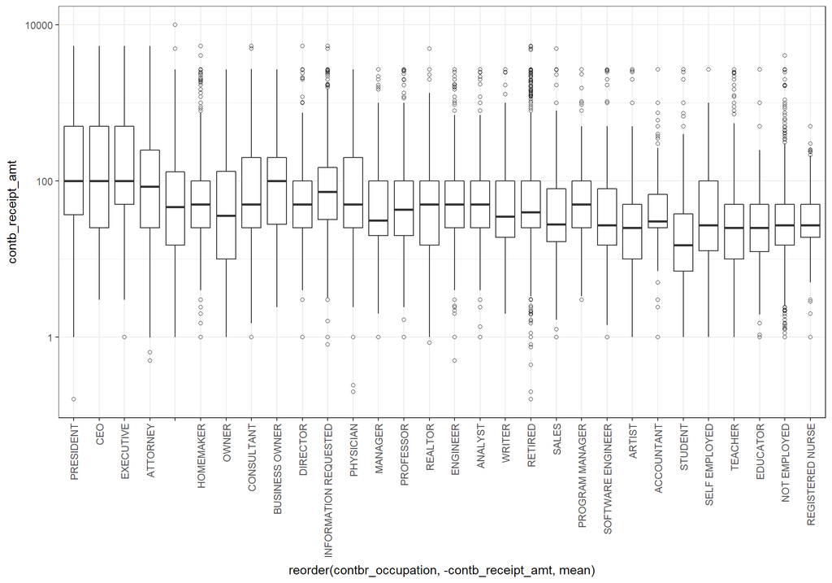

The contibution receipt amount was scaled by a log. Negative receipts were removed. Ordered by mean.

Executives have a high mean and median contribution receipt amount which is not unusual. Homemakers had a surprisingly high mean receipt amount, maybe related to executives in some way. It is also interesting that RNs had a lower mean receipt than even unemployed people. Are RNs generally less likely to contribute large amounts or is this particular to this election or state?

The maximum receipts look more even between groups than was the mean. Again, RN’s are at the bottom of the list with a significantly lower maximum contribution than the rest of the groups.

### Aggregate Receipt

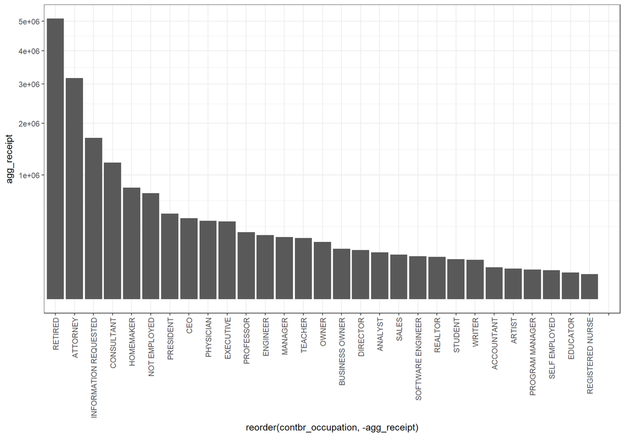

The y axis was scaled by a square root.

Overall, retired people contributed $5000000 of the $28000000 contributed this campaign. The amount quickly declines after retirees. Homemakers and unemployed people surpassed executives in aggregate contributions. Is the frequency of contributions related to the average amount of individual leisure time? That would help explain the prominence of some of the groups in this dataset.

### Summary Analysis

The contribution receipts by occupation had some interesting results. We saw from looking at the counts that the most frequent contributions came from retirees, unemployed, info requested, attorneys, and consultants, in that order. While there were around 13000 contributions from the unemployed group, their average contribution was quite small compared to the rest of the top 5 groups. Surprisingly homemakers had a higher aggregate receipt amount with only 3000 contributions.

## Receipts by Employer

### Receipts Boxplots

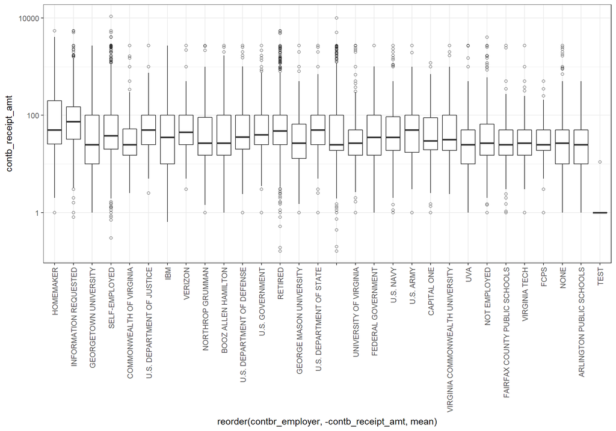

The contibution receipt amount was scaled by a log. Negative receipts were removed. Ordered by mean.

The mean receipt of homemakers in the occupation column is slightly different than the one for employer. It could be that some of the people that listed themselves as a homemaker could have left the employer section blank or written self-employed. Out of the 2998 that listed themselves as homemaker, 1259 also listed homemaker on employer. It’s interesting how many actual companies are represented in the dataset.

The maximum contribution is even between most of the employers. The self-employed and the blank groups could contain so many different types of individuals that it’s hard to get anything out of their maximum contributions.

The “TEST” group is hard to determine. It might be that some of contributions in this dataset were just test to test the system.

### Aggregate Receipt

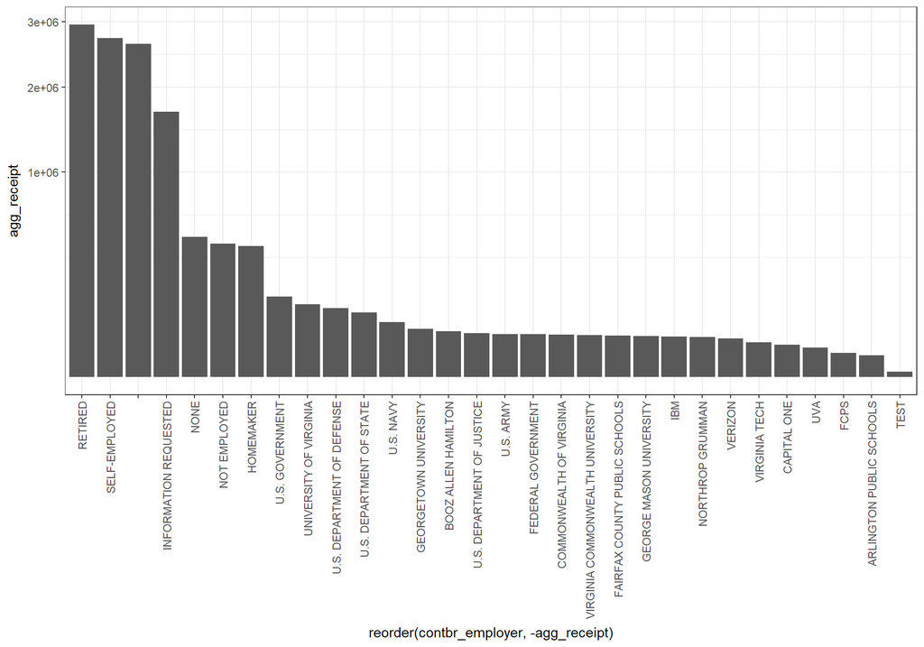

The y axis was scaled by a square root.

It isn’t surprising that the biggest groups of contributors would have the highest aggregate receipt amount. It seems that there are too many different employers to be able to gain too much information about the contributions. It is clear that large organizations or groups (retiree) will be more respresented in this list.

### Summary Analysis

The most obvious thing about the employer feature is that it is too broad. There are also many names that could be fixed or consolidated. While I was able to convert a few of the major employers (DOD, US Navy), more issues become apparent. Like I discussed earlier about cities, it might not be worth the effort to try to clean up this variable.

## Candidate Contributions by Date

### All Candidates

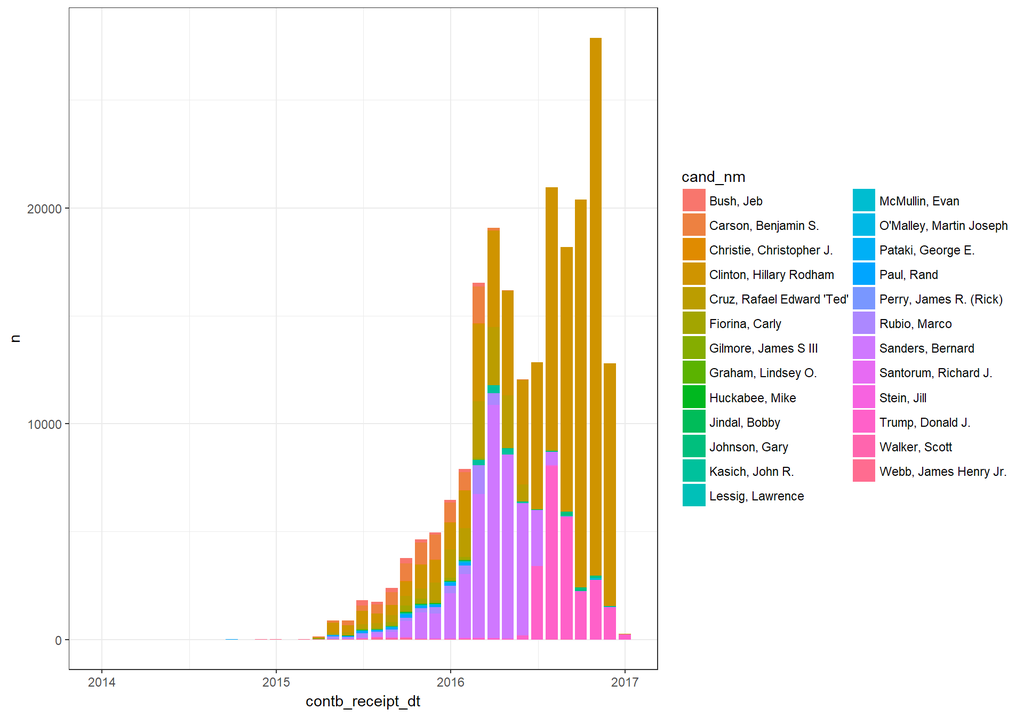

### Top 5 Candidates

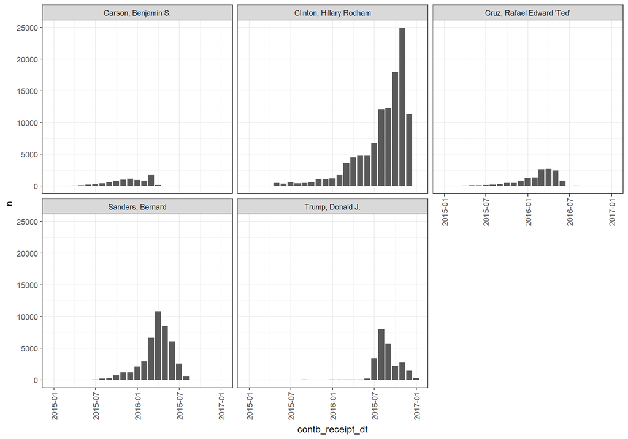

These plots paint an interesting picture of the election, at least in Virginia. The Virginia Party Primary elections were is March 2016. Looking at the contributions leading up to March, I would expect Bernie Sanders to win the Democratic delegates and a close race between the 2 Republican delegates. What we actually saw was a substantial win from Hillary Clinton and a surprising win from Donald Trump. Donald Trump had barely any contributions even up to July 2016, when the Primary elections ended. A similar thing seems to have occured during the General election. The 2 Presidential candidates had a close race in Virginia, but the contribution numbers would make me expect a landslide win by Hillary Clinton.

# Bivariate Analysis

In this part of the analysis I kept most of my attention on the monetary amounts that were contributed during this election. We can see that most of the earlier contributions might be coming from people that were more informed about the candidates that would be running in this election. I think that because the early donations had a fairly large mean. As more people started to get interested in the campaign, their smaller donations quickly brought down the averages.

When looking at contributions by city, I didn’t find it surprising that the most populated areas in Virginia would have the highest frequency of contributions. It was interesting to see some of the smaller towns have high numbers. McClean has a population of about 48 thousand people (in 2010); 5.8 thousand contributions came from this area and equaled to $2.36 million. That impressive when we consider that Alexandria’s population is 3 times as large with 4 times the contribution count but only 2 times the aggregate receipt amount.

It is clear that the contribution rates and amounts are affected by some events that are outside of the dataset. However, there seems to be some separation between contribution trends and actual voting trends. As I stated earlier, I would not have expected Donald Trump to be in the race at all if I looked at his contribution numbers before the Primary Election. Nor would I expect a close race in Virginia between Clinton and Trump.

# Multivariate Plots

## Location/Candidates Receipts

### Top 30 Cities/All Candidates

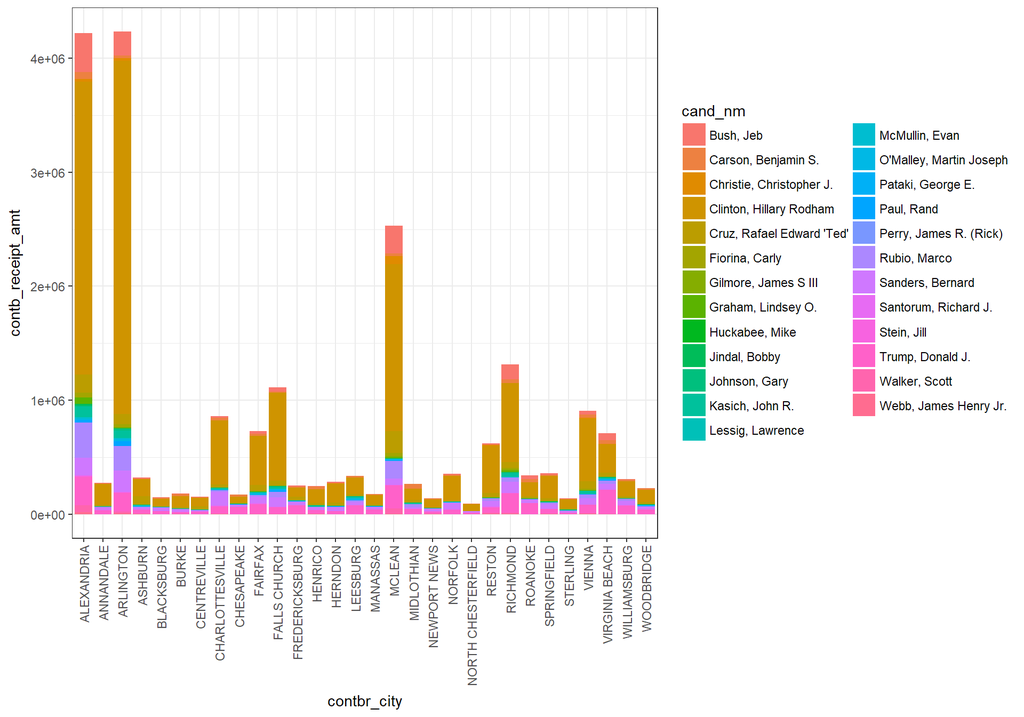

As would be expected, Hillary Clinton’s contribution receipt amount from each city overshadows the rest of the candidates.

### Top 30 Cities/All Candidates - HRC

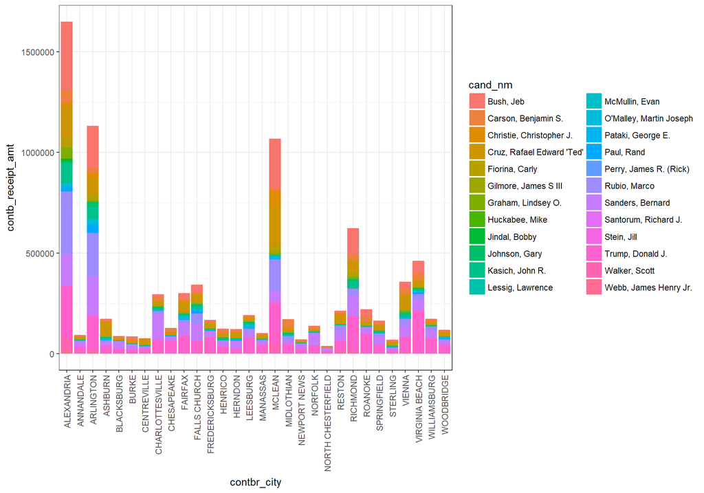

Looking at the chart with HRC helps to see that Jeb Bush actually received a relatively high contribution receipt amount from the highest contributing cities. That’s quite unexpected because he fell out of the campaign quite early.

### Top 30 Cities/Political Party

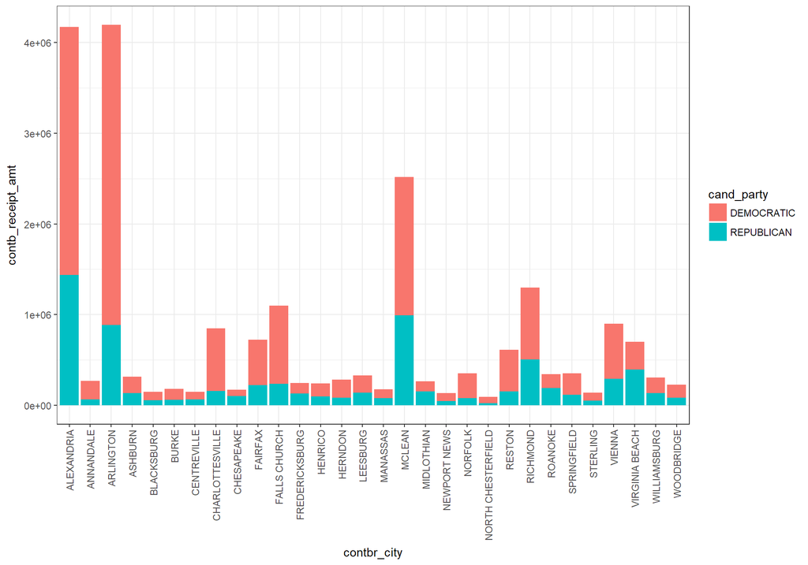

Few cities of the 30 highest contributing cities actually gave more to Republicans than Democrats. That is an obvious fact based on Hillary Clinton’s receipts. The question would be whether these campaign contributors are Democratic Party supporters or Hillary Clinton supporters.

### Top 30 Cities/Political Party - HRC

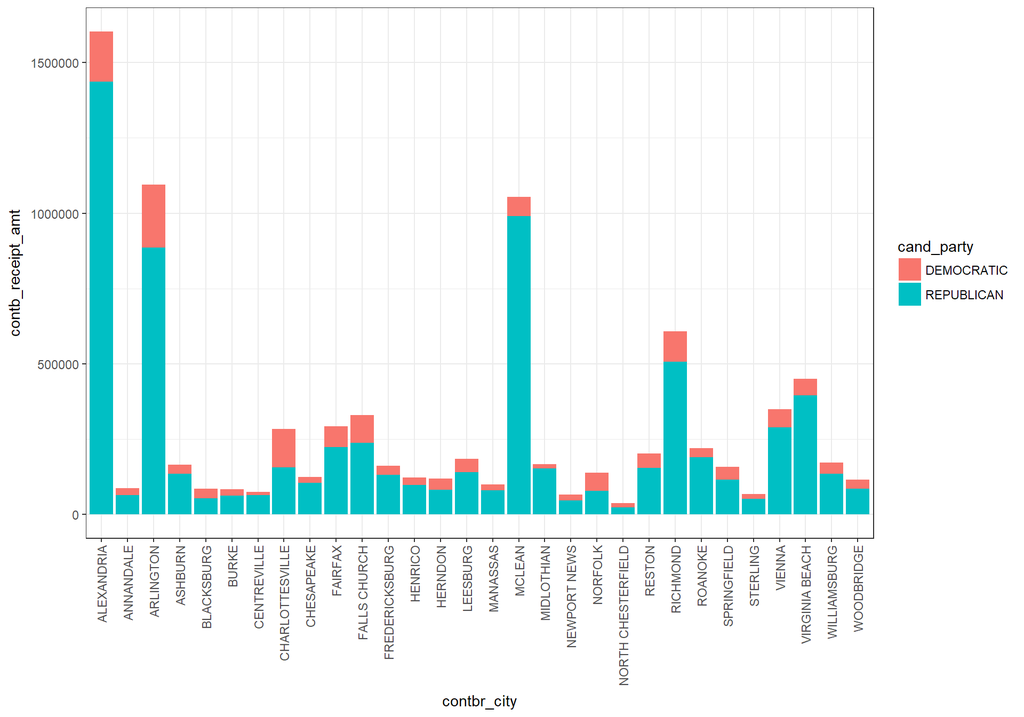

Removing HRC from the included Democrats really shows how much of the overall contributions went to her campaign rather than Democratic candidates in general. There can be many reasons for this type of contibution strategy, but I would suggest that one of the major reasons is the small pool of candidates that ran in the Democratic Primary Election.